# R HW 04: Data Wrangling II

Women’s Soccer

# Goals

In this lab, you will…

- Develop proficiency with data-wrangling functions
- Answer real research questions using related data sets

# Getting started

- Download R_HW_04.qmd and place it in the STAT_7500 folder on your computer
- From inside your STAT_7500 RStudio Project, open and render the Quarto document

# Packages

We will be using data from the `nwslR` package, which is not available on CRAN (the main repository for R packages), but can be installed from github. Run the following code in your console to install `devtools` (which is required to use the `install_github()` function) and `nwslR`. It may be a good idea to put this code in your .qmd so you know in the future that it was necessary, but you should comment it out or place it in a code chunk with `eval = FALSE` because you do not need to re-install everytime you Render.

```r
install.packages("devtools")
devtools::install_github("nwslR/nwslR",
                         ref = "v0.0.0.9002")
```

The code below loads the packages for this assignment.

```r
library(tidyverse)
library(viridis) #for viridis color scale
library(kableExtra) #for nicely formatted tables
library(ggridges) #for ridgeplots
library(nwslR) #for National Women's Soccer League data
```

# Data: The Portland Thorns FC

For this assignment, you will be working with data about the [Portland Thorns FC](https://www.nwslsoccer.com/team/portland-thorns-fc/stats), a National Women’s Soccer League (NWSL) Team in Portland, OR. In 2021, the Thorns won the NWSL Challenge Cup, the Women’s International Champions Cup, and the NWSL Shield. Data for this lab was sourced from the [nwslR package](https://github.com/adror1/nwslR).

The package comes with built-in functions that allow you to pull data from a Github repo:

- load_matches(): All matches from 2016-present with information and match IDs
- load_players(): All players rostered from 2016-present with information and player IDs
- load_teams(): All teams active from 2016-present with information and team IDs
- load_metrics() All metrics available from scrapers with definitions. Not all metrics are available for all players/matches/teams/etc.

Running the following code will make four datasets appear in your Environment.

```r
matches <- load_matches()
players <- load_players()
teams <- load_teams()
metrics <- load_metrics()
```

# Exercises

Throughout, make sure to write clean code (use linebreaks and spacing to improve readability), comment your code, and provide appropriate titles and axis labels for visualizations.

## Data Wrangling

Before beginning the analysis, you will need to conduct some data wrangling to look only at the Portland Thorns data.

1. Inspect the `teams` data to determine the `external_team_id` for the Portland Thorns. Filter the `matches` dataset to only keep matches where Portland was playing. Save this as a new dataset called `portland_matches`. *Confirm that your new data has 223 observations before proceeding.*

We want to add in information from the `teams` data into the `matches` data so we can have the team name and abbreviation in addition to just the numeric team id. However, we will have to join the `teams` information twice: once for home team and once for away team. We want to end up with the following four variables added to the `portland_matches` data:

- `home_team_name`
- `home_team_abbr`
- `away_team_name`
- `away_team_abbr`

The following code creates a new dataset called `home_team_info` that `selects` the relevant columns from `teams` and renames them to include the prefix `home_` . It then joins these columns to the `portland_matches` data.

```r
home_team_info <- teams |>
  select(home_team_id = external_team_id,
         home_team_name = team_name,
         home_team_abbr = team_abbreviation)

portland_matches <- portland_matches |>
  left_join(home_team_info)
```

2. Include the code above in your report. Then, following the above code as a template, create a similar `away_team_info` dataset that renames the columns with the prefix `away_`. Then, join those columns to `portland_matches`. *Confirm `portland_matches` has dimensions 223 x 19 before continuing.*
3. Create three new variables, `POR_points` (the number of points Portland scored), `OPP_points` (the number of points the opponent scored), and `result` (a categorical variable for whether the result was a `Win`, `Loss`, or `Tie` for Portland). *Hint: the code below provides the scaffolding, you just need to fill in each blank appropriately.*

```r
___ <- ___ |>
  ___(POR_points = if_else(home_team_abbr == "POR",
                           home_team_score, away_team_score),
      OPP_points = if_else(___ ___ ___, ___, ___),
      result = case_when(POR_points  >  OPP_points ~ "Win",
                         POR_points ___ OPP_points ~ "Loss",
                         POR_points ___ OPP_points ~ "Tie"))
```

## Match analysis

4. Create a bar chart to visualize the distribution of the `result` of the games. Include a clear title and axis labels. What outcome occurred most frequently?
5. Create an appropriate visualization to examine how the Thorns performed in each individual season (in terms of wins, losses, and ties). Include a clear title and axis labels. Describe 2-3 things you observe from the visualization.
6. *Does Portland have a home field advantage?* To explore this question:
- Create a new variable indicating whether Portland was the "home" or "away" team for each game.
- Create side-by-side box plots of the number of points scored by the Thorns based on whether or not they were the home team.
- Then create a ridge plot using `geom_density_ridges()`.
- Describe 2-3 things you observe from the visualizations.
7. Continuing to investigate home-field advantage, produce a nicely formatted summary table that presents the proportion of games won, grouped by whether it was a home or away game. Do they do better at home or away?

## Player stats

The code below loads data for players’ individual stats for the matches in `portland_matches`. Don’t worry too much about how this code is working, it is provided by the `nwslR` package. Note, it takes a few minutes to run!

```r
# * A small number of matches do not have data, so we wrap this in a safe call to ensure this runs without error
safe_load_pms <- purrr::possibly(load_player_match_stats, otherwise = data.frame())

player_stats <- purrr::map_df(portland_matches$match_id, safe_load_pms, .progress = TRUE)
```

### Which Portland players had the highest percentage of shots outside the box?

### Which Portland players made the highest percentage of their shots?

8. This is one big open-ended exercise to answer the two research questions above. It’s up to you to determine the appropriate wrangling necessary to answer the questions. A few tips for getting started:
- Filter the data to only keep Portland players
- You’ll only need the `player_id`, `team_id`, `shots_total`, `shots_outside_box`, and `goals` variables to answer these questions
- You will eventually need to join in info from the `players` data so that your end result will display the players names and not just their numerical id
- Only display data for players that took at least 15 shots
- Your end result should be either a nicely formatted table, or a nicely formatted visualization, like the ones below. Use these end results to help you decide what wrangling will help you build up to this information.

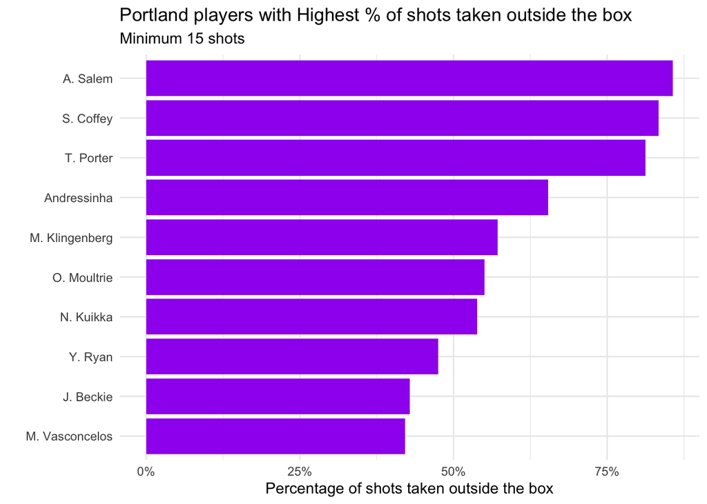

| player_match_name | shots_total | goals | prop_shots_made |
| --- | --- | --- | --- |
| E. Sonnett | 26 | 8 | 0.3076923 |
| H. Sugita | 60 | 14 | 0.2333333 |
| T. Porter | 16 | 3 | 0.1875000 |
| N. Nadim | 81 | 15 | 0.1851852 |
| C. Sinclair | 322 | 54 | 0.1677019 |
| H. Betfort | 30 | 5 | 0.1666667 |
| D. Brynjarsdóttir | 41 | 6 | 0.1463415 |
| H. Raso | 97 | 13 | 0.1340206 |
| A. Long | 63 | 8 | 0.1269841 |
| M. Purce | 63 | 8 | 0.1269841 |

## BONUS

What is an additional question you could investigate using this data? State the question, provide a visualization and/or table that investigates it, and comment on what your output shows.

# Submission

Check again for neatness & organization of your .html.

To submit, render one last time, then export your html as a .pdf and upload the pdf document to the relevant assignment on Blackboard. Refer back to R HW 01 for detailed instructions on how to submit your assignment.

# Grading

| Component | Points |
| --- | --- |
| Ex 1 | 1 |
| Ex 2 | 1 |
| Ex 3 | 1 |
| Ex 4 | 1 |
| Ex 5 | 1 |
| Ex 6 | 1 |
| Ex 7 | 1 |
| Ex 8 | 2 |
| Neatness & Organization | 0.5 |
| Reflection prompts | 0.5 |